# Meta Heuristics 1

Evan Carey

# Overview

- Importing spatial data into R
- The ‘traveling salesman’ problem for Missouri FQHC

# Import Spatial Data

- R is actually a fully featured GIS system. We can import a shape file using the rgdal library and the readOGR function.
- This will retain the projection information about the shapefile.
- The resulting file is a ‘spatialpointsdataframe’ - a dataframe of spatially indexed points.

```r
## import Missouri FQHC shapefile
library(rgdal)
data_path <- 'MO_2018_Federally_Qualified_Health_Center_Locations'
MO_FQHC <-
  readOGR(data_path,
          'MO_2018_Federally_Qualified_Health_Center_Locations')
## examine data
class(MO_FQHC)
```

```
## [1] "SpatialPointsDataFrame"
## attr(,"package")
## [1] "sp"
```

```r
summary(MO_FQHC)
```

```
## Object of class SpatialPointsDataFrame
## Coordinates:
##                 min       max
## coords.x1 -95.23779 -89.38704
## coords.x2  36.23222  40.43782
## Is projected: FALSE
## proj4string : [+proj=longlat +datum=WGS84 +no_defs]
## Number of points: 197
## Data attributes:
##    OBJECTID          Group_Name          Facility           Address
##  Length:197         Length:197         Length:197         Length:197
##  Class :character   Class :character   Class :character   Class :character
##  Mode  :character   Mode  :character   Mode  :character   Mode  :character
##
##
##
##      City              County             State               Zip
##  Length:197         Length:197         Length:197         Length:197
##  Class :character   Class :character   Class :character   Class :character
##  Mode  :character   Mode  :character   Mode  :character   Mode  :character
##
##
##
##     Phone              Latitude       Longitude        Loc_Code
##  Length:197         Min.   :36.23   Min.   :-95.24   Length:197
##  Class :character   1st Qu.:37.21   1st Qu.:-93.80   Class :character
##  Mode  :character   Median :38.44   Median :-92.43   Mode  :character
##                     Mean   :38.24   Mean   :-92.24
##                     3rd Qu.:39.06   3rd Qu.:-90.43
##                     Max.   :40.44   Max.   :-89.39
```

```r
head(MO_FQHC)
```

```
##             coordinates OBJECTID                     Group_Name
## 1 (-90.55472, 38.43597)        1                        COMTREA
## 2 (-91.13403, 37.71462)        2 Missouri Highlands Health Care
## 3 (-92.60144, 38.16025)        3  Central Ozarks Medical Center
## 4 (-90.45724, 36.77261)        4 Missouri Highlands Health Care
## 5  (-94.49886, 38.9629)        5          Swope Health Services
## 6 (-91.35847, 37.14414)        6 Missouri Highlands Health Care
##                                                       Facility
## 1                            COMTREA Byrnes Mill Health Center
## 2                                      Viburnum Medical Clinic
## 3                    Central Ozarks Medical Center At The Lake
## 4 Missouri Highland Medical Clinic - Poplar Bluff Medical Park
## 5                                   Swope Health Hickman Mills
## 6                                 Shannon County Family Clinic
##                                Address          City    County State   Zip
## 1           100 Osage Executive Circle House Springs Jefferson    MO 63051
## 2              18 Viburnum Center Road      Viburnum      Iron    MO 65566
## 3                 3870 Columbia Avenue   Osage Beach    Miller    MO 65065
## 4 225 Physicians Park Drive, Suite 303  Poplar Bluff    Butler    MO 63901
## 5            8800 Blue Ridge Boulevard   Kansas City   Jackson    MO 64138
## 6                  1003 S. Main Street      Eminence   Shannon    MO 65466
##        Phone Latitude Longitude Loc_Code
## 1 6367893372 38.43595 -90.55468      MAP
## 2 5732445406 37.71462 -91.13398      MAP
## 3 5733027490 38.16026 -92.60146      MAP
## 4 5737856536 36.77257 -90.45721      MAP
## 5 8163213200 38.96288 -94.49885      MAP
## 6 5732265505 37.14414 -91.35846      MAP
```

```r
names(MO_FQHC)
```

```
##  [1] "OBJECTID"   "Group_Name" "Facility"   "Address"    "City"
##  [6] "County"     "State"      "Zip"        "Phone"      "Latitude"
## [11] "Longitude"  "Loc_Code"
```

```r
## get projection
proj4string(MO_FQHC)
```

```
## [1] "+proj=longlat +datum=WGS84 +no_defs"
```

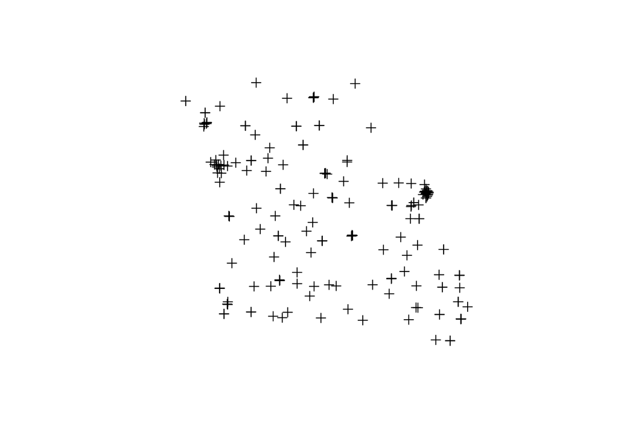

```r
## show map with base R
plot(MO_FQHC)
```

# Motivating problem

- Suppose we want to calculate the shortest route between some of the FQHC’s in Missouri. We will start with only 3 centers.
- We will need to calculate the distance between each one of the centers.
- We can then evaluate different routes using that distance matrix, and identify the optimal (shortest) route.

# Calculating the distance between two points.

- I am going to convert this shapefile to a dataframe with lat/lon to make things easier.
- There is a geodesic function in the geosphere package which can calculate ‘great circle’ distances. We will use that to represent distance. Note you could use fancier functions which account for the WGS84 projection to gain even more accuracy.

```r
#### Calculate distance between two clinics
## First must convert to dataframe (Easier to handle)
library(data.table)
MO_FQHC_df <-
  data.table(as.data.frame(MO_FQHC))
```

```r
## use geodesic function
## this returns distance in meters!
## divide by 1609.344 to get miles
library(geosphere)
xy <- rbind(c(0,0),
            c(90,90),
            c(10,10),
            c(-120,-45))
distm(xy,fun=distHaversine)/1609.344
```

```
##           [,1]     [,2]      [,3]     [,4]
## [1,]    0.0000 6225.365  975.7253 7657.532
## [2,] 6225.3652    0.000 5533.6580 9338.048
## [3,]  975.7253 5533.658    0.0000 8631.003
## [4,] 7657.5320 9338.048 8631.0034    0.000
```

- This function is vectorized. If we pass in multiple points, we will get back a matrix of distances to all points.
- Let’s subset to only the first three data points:

```r
## subset to only 3 clinics for now
sites3 <-
  MO_FQHC_df[1:3,list(OBJECTID=as.character(OBJECTID),Longitude,Latitude)]
```

- Now we can calculate the pairwise geodesic distances using the function we just demonstrated:

```r
## create distance matrix
dist_mat3 <-
  distm(sites3[,list(Longitude,Latitude)],
        fun=distHaversine)/1609.344
colnames(dist_mat3) <- sites3$OBJECTID
rownames(dist_mat3) <- sites3$OBJECTID
dist_mat3
```

```
##           1        2         3
## 1   0.00000 59.02925 112.73168
## 2  59.02925  0.00000  85.78468
## 3 112.73168 85.78468   0.00000
```

# Generating all possible combinations

- Now that we have the distances, can you generate all the possible routes we could take ?
- This is called generating a ‘permutation’. There is an R function for that (of course) in the gtools package.

```r
# generate all combinations of vector of 3 locations?
expand.grid(c(1,2,3),
            c(1,2,3),
            c(1,2,3))
```

```
##    Var1 Var2 Var3
## 1     1    1    1
## 2     2    1    1
## 3     3    1    1
## 4     1    2    1
## 5     2    2    1
## 6     3    2    1
## 7     1    3    1
## 8     2    3    1
## 9     3    3    1
## 10    1    1    2
## 11    2    1    2
## 12    3    1    2
## 13    1    2    2
## 14    2    2    2
## 15    3    2    2
## 16    1    3    2
## 17    2    3    2
## 18    3    3    2
## 19    1    1    3
## 20    2    1    3
## 21    3    1    3
## 22    1    2    3
## 23    2    2    3
## 24    3    2    3
## 25    1    3    3
## 26    2    3    3
## 27    3    3    3
```

```r
# Just use the permutations function.
library(gtools)
permutations(3,3,letters[1:3])
```

```
##      [,1] [,2] [,3]
## [1,] "a"  "b"  "c"
## [2,] "a"  "c"  "b"
## [3,] "b"  "a"  "c"
## [4,] "b"  "c"  "a"
## [5,] "c"  "a"  "b"
## [6,] "c"  "b"  "a"
```

```r
# How many do we expect?
3*2*1
```

```
## [1] 6
```

- We can repeat this for our object ID’s from our dataset:

```r
# do this for our object IDS
perms_3 <-
  permutations(3,3,sites3$OBJECTID)
```

- These are the potential routes (or paths) we might take.

```r
# these are our 'paths' (routes)
# write function to calculate the distance for a single route (ith route)
# generate matrix of path steps for this route
i <- 1
i_perms_3 <- perms_3[i,]
# break apart into pairs of points defining the route
temp_mat_path <-
  rbind(i_perms_3[-length(i_perms_3)],i_perms_3[-1])
temp_mat_path
```

```
##      [,1] [,2]
## [1,] "1"  "2"
## [2,] "2"  "3"
```

```r
# lookup distances using this matrix and sum
sum(apply(X = temp_mat_path,
      MARGIN = 2,
      FUN = function(x) dist_mat3[x[1],x[2]]))
```

```
## [1] 144.8139
```

- Let’s generalize that code to an R function that will calculate the total distance for a single given route:

```r
# write function to calculate the distance for a single route (i'th route)
path_dist_func <-
  function(pathVec,distMat) {
    temp_mat_path <-
      rbind(pathVec[-length(pathVec)],
            pathVec[-1])
    dist <- sum(apply(X = temp_mat_path,
                      MARGIN = 2,
                      FUN = function(x) distMat[x[1],x[2]]))
    return(dist)
}
```

- Now we can test this function to make sure it works as expected:

```r
## Test function
dist_mat3
```

```
##           1        2         3
## 1   0.00000 59.02925 112.73168
## 2  59.02925  0.00000  85.78468
## 3 112.73168 85.78468   0.00000
```

```r
perms_3[1,]
```

```
## [1] "1" "2" "3"
```

```r
path_dist_func(perms_3[1,],dist_mat3)
```

```
## [1] 144.8139
```

```r
perms_3[2,]
```

```
## [1] "1" "3" "2"
```

```r
path_dist_func(perms_3[2,],dist_mat3)
```

```
## [1] 198.5164
```

```r
perms_3[3,]
```

```
## [1] "2" "1" "3"
```

```r
path_dist_func(perms_3[3,],dist_mat3)
```

```
## [1] 171.7609
```

- If we want to apply this function across all the rows of a matrix, we can use the apply function:

```r
## Apply this function to our paths (permutations)
apply(perms_3,
      MARGIN = 1,
      FUN = path_dist_func,
      distMat = dist_mat3)
```

```
## [1] 144.8139 198.5164 171.7609 198.5164 171.7609 144.8139
```

- Now let’s add this to our path matrix:

```r
## add to path matrix
cbind(perms_3,
      apply(perms_3,
            MARGIN = 1,
            FUN = path_dist_func,
            distMat = dist_mat3))
```

```
##      [,1] [,2] [,3] [,4]
## [1,] "1"  "2"  "3"  "144.81392261232"
## [2,] "1"  "3"  "2"  "198.51635613681"
## [3,] "2"  "1"  "3"  "171.760928255438"
## [4,] "2"  "3"  "1"  "198.51635613681"
## [5,] "3"  "1"  "2"  "171.760928255438"
## [6,] "3"  "2"  "1"  "144.81392261232"
```

```r
## converted to all character! (matrix is all one type...)
```

- Whoops, a matrix is not ideal here. Let’s use a dataframe:

```r
## use dataframe instead
perms_3_df <-
  data.frame(perms_3)
perms_3_df$distance <-
  apply(perms_3,
        MARGIN = 1,
        FUN = path_dist_func,
        distMat = dist_mat3)
perms_3_df
```

```
##   X1 X2 X3 distance
## 1  1  2  3 144.8139
## 2  1  3  2 198.5164
## 3  2  1  3 171.7609
## 4  2  3  1 198.5164
## 5  3  1  2 171.7609
## 6  3  2  1 144.8139
```

- Finally, we can search these distances for the minimum:

```r
# Find min
perms_3_df[perms_3_df$distance == min(perms_3_df$distance),]
```

```
##   X1 X2 X3 distance
## 1  1  2  3 144.8139
## 6  3  2  1 144.8139
```

# Expanding to more sites - Class activity

- Let’s say we want to visit 8 sites instead of only 3 sites…
- How many possible combinations are there? (hint: use the factorial function)
- Use a similar approach as I did above to give me an answer for the optimal path using 8 sites.

```r
## what if we want to visit 8 sites?

## How many possible combinations are there?
```

```r
## implement the brute force approach to the first 8 sites as I did above. Whats the best order to visit them?
```

- What about visiting 20 sites? Can you implement code to brute force search for 20 sites?

```r
## Implement the brute force approach for 20 sites.
## How big will the matrix be?


## what about 25 sites?


## you need a big computer!
## this is NP hard!
```